# TP3 – ANOVA à un facteur

- Montrer tout le code
- Cacher tout le code
- Voir les sources

Auteur·rice

HAMLIL Mohamed

Date de publication

2025

# Introduction

Le but de cette séance est de s’éclairer sur le **lien potentiel entre l’abolition de la peine de mort et le taux de criminalité** aux États-Unis.

Les données proviennent du site du FBI. Elles donnent le nombre de meurtres dans les différents états des États-Unis en 2009 ainsi que la population. Pour s’affranchir des différences de tailles de populations, on utilise le **taux de criminalité pour 1000 habitants**.

Nous étudierons ensuite un second jeu de données sur l’**absorption de matière grasse par des beignets**, un cas classique d’**ANOVA à un facteur**.

# 1. Acquisition des données

```r
data = read.csv2("murderusa.csv")
head(data)
```

A data.frame: 6 × 5

|  | State <chr> | Population..en.milliers. <int> | Total.murders..2009. <int> | tauxmeurtres <dbl> | PDMabolie09 <chr> |
| --- | --- | --- | --- | --- | --- |
| 1 | Vermont | 622 | 7 | 0.113 | oui |
| 2 | Iowa | 3008 | 34 | 0.113 | oui |
| 3 | Minnesota | 5266 | 72 | 0.137 | oui |
| 4 | North Dakota | 647 | 9 | 0.139 | oui |
| 5 | Hawaii | 1295 | 21 | 0.162 | oui |
| 6 | Maine | 1318 | 26 | 0.197 | oui |

Affectons les variables :

```r
txcrime09 = data$tauxmeurtres
PDMabolie09 = data$PDMabolie09
```

Créons deux sous-groupes : états ayant **aboli** la peine de mort et ceux ne l’ayant **pas aboli** :

```r
abolie09 = txcrime09[PDMabolie09 == "oui"]
nonabolie09 = txcrime09[PDMabolie09 == "non"]

# Conversion en numérique si nécessaire
abolie09 = as.numeric(abolie09)
nonabolie09 = as.numeric(nonabolie09)

cat("Nombre d'états ayant aboli :", length(abolie09))
cat("\nNombre d'états n'ayant pas aboli :", length(nonabolie09))
```

```
Nombre d'états ayant aboli : 13
Nombre d'états n'ayant pas aboli : 37
```

# 2. Effet de l’abolition sur le taux de meurtres

## 2.1 Statistiques descriptives

### Boîtes à moustaches

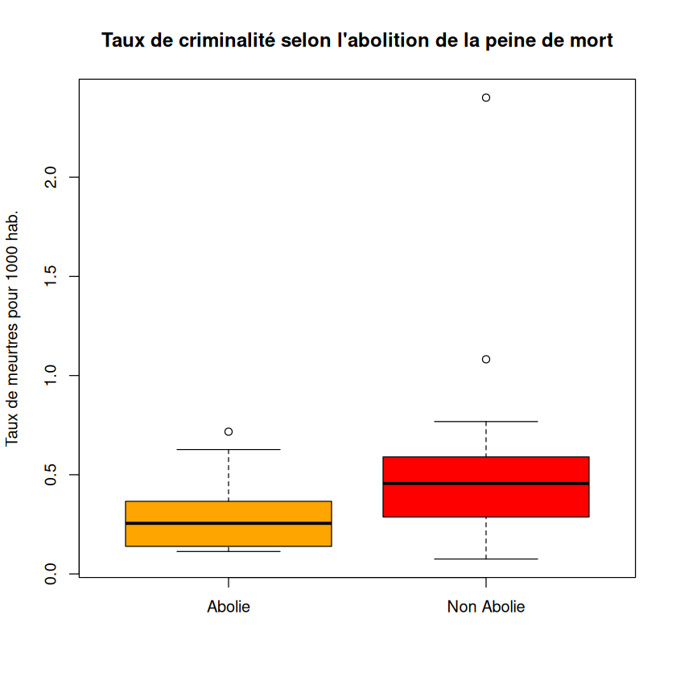

```r
boxplot(abolie09, nonabolie09,
        main = "Taux de criminalité selon l'abolition de la peine de mort",
        col = c("orange", "red"),
        names = c("Abolie", "Non Abolie"),
        ylab = "Taux de meurtres pour 1000 hab.")
```

On peut aussi utiliser directement la formule :

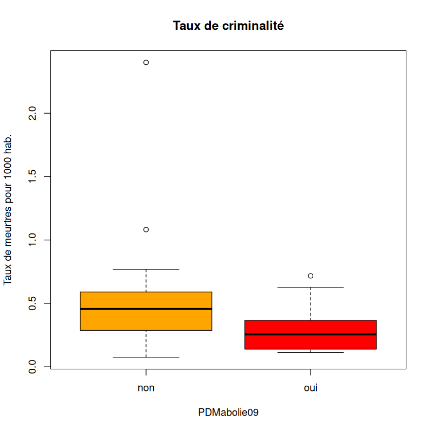

```r
boxplot(txcrime09 ~ PDMabolie09,
        main = "Taux de criminalité",
        col = c("orange", "red"),
        ylab = "Taux de meurtres pour 1000 hab.")
```

**Observations :**

- Tous les indicateurs (médiane, quartiles) sont **plus bas** dans les états ayant aboli la peine de mort.
- Le taux de criminalité est **globalement plus bas** dans les états ayant aboli.
- **Attention :** Aucun lien de cause à effet ne peut être dégagé ! (Est-ce l’abolition qui fait baisser le taux ? Est-ce un taux bas qui permet d’abolir ? Ou n’y a-t-il aucun lien ?)

### Comparaison des moyennes

```r
cat("Moyenne (abolie) :", mean(abolie09))
cat("\nMoyenne (non abolie) :", mean(nonabolie09))
```

```
Moyenne (abolie) : 0.2963846
Moyenne (non abolie) : 0.494973
```

## 2.2 ANOVA

On teste si la différence entre les groupes est **statistiquement significative** :

```r
summary(aov(txcrime09 ~ PDMabolie09))
```

```
            Df Sum Sq Mean Sq F value Pr(>F)
PDMabolie09  1  0.379  0.3794   3.172 0.0812 .
Residuals   48  5.740  0.1196
---
Signif. codes:  0 ‘***’ 0.001 ‘**’ 0.01 ‘*’ 0.05 ‘.’ 0.1 ‘ ’ 1
```

On obtient le même résultat avec `anova` :

```r
anova(lm(txcrime09 ~ PDMabolie09))
```

A anova: 2 × 5

|  | Df <int> | Sum Sq <dbl> | Mean Sq <dbl> | F value <dbl> | Pr(>F) <dbl> |
| --- | --- | --- | --- | --- | --- |
| PDMabolie09 | 1 | 0.3793872 | 0.3793872 | 3.172317 | 0.08122444 |
| Residuals | 48 | 5.7404680 | 0.1195931 | NA | NA |

**Interprétation :** La p-value est **trop grande** pour rejeter l’égalité des moyennes. On **ne peut pas affirmer** qu’il y a un lien significatif entre l’abolition de la peine de mort et le taux de criminalité.

## 2.3 Retrouver les résultats du tableau d’ANOVA

### SCM (Somme des Carrés du Modèle)

$$SCM = \sum_{i=1}^{2} n_i (\bar{X}_i - \bar{X})^2$$

```r
SCM = length(abolie09) * (mean(abolie09) - mean(txcrime09))^2 +
      length(nonabolie09) * (mean(nonabolie09) - mean(txcrime09))^2
cat("SCM =", round(SCM, 6))
```

```
SCM = 0.379387
```

### SCE (Somme des Carrés des Erreurs)

$$SCE = \sum_{i=1}^{2} \sum_{j=1}^{n_i} (X_{ij} - \bar{X}_i)^2$$

```r
SCE = sum((abolie09 - mean(abolie09))^2) +
      sum((nonabolie09 - mean(nonabolie09))^2)
cat("SCE =", round(SCE, 6))
```

```
SCE = 5.740468
```

### Statistique de Fisher

$$F_{obs} = \frac{SCM / (2-1)}{SCE / (50-2)} = \frac{SCM}{SCE / 48}$$

```r
Fobs = SCM / (SCE / 48)
cat("F observé =", round(Fobs, 4))
```

```
F observé = 3.1723
```

### p-value

La variable du test suit une loi de Fisher $\mathcal{F}_{1, 48}$ :

```r
pval = 1 - pf(Fobs, 1, 48)
cat("p-value =", round(pval, 4))
```

```
p-value = 0.0812
```

# 3. Et en 2016 ?

Des résultats similaires ont été montrés en 2016 en L2. On peut charger le fichier `crime16.csv` pour une analyse comparable :

```r
crime16 = read.csv2("crime16.csv")
head(crime16)
```

A data.frame: 6 × 2

|  | crime_nonabo <dbl> | crime_abo <dbl> |
| --- | --- | --- |
| 1 | 532.3 | 123.8 |
| 2 | 470.1 | 158.3 |
| 3 | 550.9 | 227.1 |
| 4 | 445.3 | 238.9 |
| 5 | 372.2 | 242.6 |
| 6 | 501.8 | 245.0 |

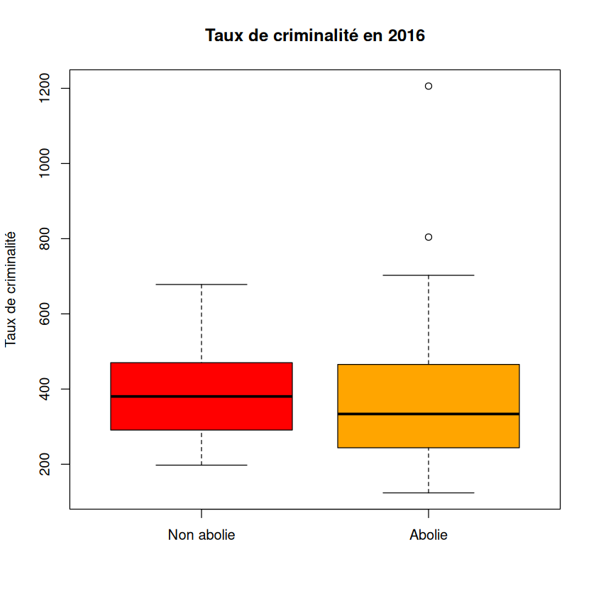

```r
boxplot(crime16$crime_nonabo, crime16$crime_abo,
        names = c("Non abolie", "Abolie"),
        main = "Taux de criminalité en 2016",
        col = c("red", "orange"),
        ylab = "Taux de criminalité")
```

# 4. Beignets et matière grasse

## 4.1 Contexte

On étudie la variable « quantité de matière grasse absorbée par des beignets durant leur cuisson ». Pour chacune des **4 matières grasses**, on a constitué 6 fournées de 24 beignets chacune. Les valeurs ont été simplifiées en soustrayant 100g.

C’est une **classification à une seule voie** : chaque matière grasse représente un **niveau du facteur**.

## 4.2 Acquisition des données

```r
rm(list = ls())
donnees <- read.table("beignets.txt", header = TRUE)
head(donnees)
```

A data.frame: 6 × 2

|  | Gras <int> | Gr <int> |
| --- | --- | --- |
| 1 | 64 | 1 |
| 2 | 72 | 1 |
| 3 | 68 | 1 |
| 4 | 77 | 1 |
| 5 | 56 | 1 |
| 6 | 95 | 1 |

```r
X = donnees[, "Gras"]
Groupe = factor(donnees[, "Gr"])
cat("Niveaux du facteur :", levels(Groupe))
cat("\nNombre d'observations :", length(X))
```

```
Niveaux du facteur : 1 2 3 4
Nombre d'observations : 24
```

> **Note :** Bien que codée de 1 à 4, la variable `Groupe` n’est pas numérique, c’est un **facteur**. C’est pour cela qu’on utilise `factor()`.

## 4.3 Test de normalité par groupe

Avant de faire une ANOVA, on vérifie l’hypothèse de normalité dans chaque groupe :

```r
tapply(X, Groupe, shapiro.test)
```

```
$`1`

    Shapiro-Wilk normality test

data:  X[[i]]
W = 0.95004, p-value = 0.7406


$`2`

    Shapiro-Wilk normality test

data:  X[[i]]
W = 0.93162, p-value = 0.5926


$`3`

    Shapiro-Wilk normality test

data:  X[[i]]
W = 0.9334, p-value = 0.6066


$`4`

    Shapiro-Wilk normality test

data:  X[[i]]
W = 0.88836, p-value = 0.3097
```

**Conclusion :** On ne rejette la normalité dans **aucun** groupe → on peut utiliser l’ANOVA.

## 4.4 Tableau d’ANOVA

```r
summary(aov(X ~ Groupe))
```

```
            Df Sum Sq Mean Sq F value  Pr(>F)
Groupe       3   1636   545.5   5.406 0.00688 **
Residuals   20   2018   100.9
---
Signif. codes:  0 ‘***’ 0.001 ‘**’ 0.01 ‘*’ 0.05 ‘.’ 0.1 ‘ ’ 1
```

```r
anova(lm(X ~ Groupe))
```

A anova: 2 × 5

|  | Df <int> | Sum Sq <dbl> | Mean Sq <dbl> | F value <dbl> | Pr(>F) <dbl> |
| --- | --- | --- | --- | --- | --- |
| Groupe | 3 | 1636.5 | 545.5 | 5.406343 | 0.006875948 |
| Residuals | 20 | 2018.0 | 100.9 | NA | NA |

**Conclusion :** On rejette l’égalité des moyennes → il y a un **effet significatif** du type de graisse sur l’absorption.

## 4.5 Contrastes

On souhaite tester l’hypothèse que les matières grasses **d’origine animale** (groupes 1 et 2) sont absorbées de la même façon que celles **d’origine végétale** (groupes 3 et 4) :

$$\frac{\mu_1 + \mu_2}{2} = \frac{\mu_3 + \mu_4}{2} \iff \mu_1 + \mu_2 - \mu_3 - \mu_4 = 0$$

Les coefficients du contraste sont $\lambda = (1, 1, -1, -1)$.

```r
lambda.i = c(1, 1, -1, -1)
xbar.i = tapply(X, Groupe, mean)
cat("Moyennes par groupe :\n")
print(xbar.i)
```

```
Moyennes par groupe :
 1  2  3  4
72 85 76 62
```

```r
n = length(X)
n.i = tapply(rep(1, n), Groupe, sum)
a = length(levels(Groupe))

# Somme des carrés des erreurs
Q.i = tapply(X, Groupe, var) * (n.i - 1)
SCE = sum(Q.i)
dl = n - a
CME = SCE / dl

# Contraste et test de Student
phi = sum(xbar.i * lambda.i)
s.phi = sqrt(CME * sum(lambda.i^2 / n.i))
tvalue = (phi - 0) / s.phi
pvaleur = pt(tvalue, dl)
pvaleur = 2 * min(pvaleur, 1 - pvaleur)

cat("Contraste estimé φ̂ =", round(phi, 2))
cat("\nÉcart-type s(φ̂) =", round(s.phi, 2))
cat("\nStatistique t =", round(tvalue, 4))
cat("\np-value =", round(pvaleur, 4))
cat("\nDegrés de liberté =", dl)
```

```
Contraste estimé φ̂ = 19
Écart-type s(φ̂) = 8.2
Statistique t = 2.3166
p-value = 0.0313
Degrés de liberté = 20
```

**Conclusion :** La nature de la matière grasse (animale vs végétale) a une **influence significative** sur l’absorption.

### Fonction de test de contraste

On peut encapsuler ce test dans une fonction réutilisable :

```r
contrast.test = function(X, Groupe, lambda.i, phi0 = 0) {
  xbar.i = tapply(X, Groupe, mean)
  n = length(X)
  a = length(levels(Groupe))
  n.i = tapply(rep(1, n), Groupe, sum)
  Q.i = tapply(X, Groupe, var) * (n.i - 1)
  SCE = sum(Q.i)
  dl = n - a
  CME = SCE / dl
  phi = sum(xbar.i * lambda.i)
  s.phi = sqrt(CME * sum(lambda.i^2 / n.i))
  tvalue = (phi - phi0) / s.phi
  pvaleur = pt(tvalue, dl)
  pvaleur = 2 * min(pvaleur, 1 - pvaleur)
  return(list(c(phi.hat = phi, s.phi = s.phi),
              c(t = tvalue, p.value = pvaleur), dl = dl))
}

contrast.test(X, Groupe, c(1, 1, -1, -1), phi0 = 0)
```

**[[1]]**

**phi.hat**

19

**s.phi**

8.20162585507695

**[[2]]**

**t**

2.31661384410003

**p.value**

0.0312510602796205

**$dl**

20

## 4.6 Construction du tableau d’ANOVA à la main

Pour bien comprendre l’ANOVA, construisons le tableau pas à pas :

```r
a <- length(levels(Groupe))
n <- length(X)

# Tailles de chaque groupe
n.i <- tapply(rep(1, n), Groupe, sum)

# Moyennes de chaque groupe
xbar.i <- tapply(X, Groupe, mean)

# Variation dans chaque groupe
Q.i <- tapply(X, Groupe, var) * (n.i - 1)

# Sommes des carrés
SCT <- (n - 1) * var(X)
SCE <- sum(Q.i)
SCM <- SCT - SCE

# Degrés de liberté
dlE <- n - a
dlM <- a - 1

# Carrés moyens
CMM <- SCM / dlM
CME <- SCE / dlE

# Statistique de Fisher et p-value
F.obs <- CMM / CME
seuil.crit <- 1 - pf(F.obs, dlM, dlE)
```

```r
# Construction du tableau
Anova.tableau <- matrix(
  c(SCM, SCE, SCT, dlM, dlE, NA, CMM, CME, NA, F.obs, NA, NA, seuil.crit, NA, NA),
  nrow = 3,
  dimnames = list(c("Inter groupe", "Intra groupe", "Totale"),
                  c("SC", "dl", "CM", "F.obs", "Pr(F)"))
)
Anova.tableau
```

A matrix: 3 × 5 of type dbl

|  | SC | dl | CM | F.obs | Pr(F) |
| --- | --- | --- | --- | --- | --- |
| Inter groupe | 1636.5 | 3 | 545.5 | 5.406343 | 0.006875948 |
| Intra groupe | 2018.0 | 20 | 100.9 | NA | NA |
| Totale | 3654.5 | NA | NA | NA | NA |

# Résumé

| Concept | Description | Fonction R |
| --- | --- | --- |
| Boxplot comparatif | Comparer deux distributions | `boxplot(x ~ facteur)` |
| ANOVA à 1 facteur | Tester l’égalité des moyennes | `anova(lm())`, `aov()` |
| SCM, SCE, SCT | Décomposition de la variance | Calcul manuel |
| Contrastes | Tester une combinaison linéaire des moyennes | Fonction personnalisée |
| `tapply` | Appliquer une fonction par sous-groupe | `tapply(var, facteur, fun)` |

**Points clés :**

- L’ANOVA teste si la différence entre les moyennes des groupes est significative.
- Avant de faire une ANOVA, il faut vérifier la **normalité** dans chaque groupe.
- L’ANOVA ne permet pas de conclure à un lien de **cause à effet**.
- Les contrastes permettent de tester des hypothèses plus fines sur les moyennes.